# PART 3

# STRENGTH OF COLUMNS WITH STABLE CROSS-SECTIONS

(BY PROFESSOR E. F. BRUHN)

## A18.22 Methods of Column Failure. Column Equations.

第1部では、柱の弾性および非弾性不安定性の理論が提示された。ピン端部支持条件における第1部からの方程式は以下の通りである。

弾性一次破壊の場合、

$$F_c = \frac{\pi^2E}{(L/\rho)^2}
\qquad\text{--- (1)}$$

非弾性一次破壊の場合、

$$F_c = \frac{\pi^2E_t}{(L/\rho)^2}
\qquad\text{--- (2)}$$

ここで、 $F_c$ = 破壊時の圧縮単位応力 = $P/A$ 応力。  
$E$ = ヤング率  
$E_t$ = 接線係数  
$L$ = 柱の長さ  
$\rho$ = 断面の回転半径

図16は、 $F_c$ と $L/\rho$ の典型的なプロットを示している。柱の寸法が図16の範囲CDで破壊するようなものである場合、一次破壊は弾性不安定性によるものであり、式(1)が成り立つ。この $L/\rho$ の範囲は、エンジニアによってしばしば長柱範囲と呼ばれる。

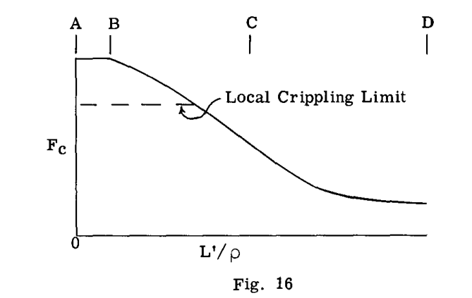

図16

範囲BCは、柱全体の非弾性不安定性によって破壊が生じる $L/\rho$ 値の範囲を表し、式(2)が適用される。この範囲BCは、しばしば短柱範囲と呼ばれる。

図16の範囲ABは、 $L/\rho$ の値が20から25未満の範囲であり、柱の塑性圧壊による破壊が生じる範囲を表している。言い換えれば、柱が短すぎて端部荷重下で座屈したりたわんだりせず、高い応力下で圧壊する。この柱の応力範囲は、通常、ブロック圧縮強度と呼ばれる。

しかし、柱は、それ自体の平面内における柱断面の歪みによる局所座屈またはクリップリング（圧壊）によって破壊することがある。図16の水平破線は、一次柱強度が局所的な弱さによって制限される条件を表している。この線は、局所的な弱さの値に応じて上下に移動する。破壊が局所的な弱さによるものである場合の柱強度の決定は、第2巻で扱われる。

## A18.23 Column End Restraint. Fixity Coefficients. Column Effective Length.

柱の強度は、回転に対する端部支持拘束および柱端部間の横方向支持によって影響を受ける。文字 $c$ は一般に端部固定度係数を示すために使用され、回転に対する端部拘束がゼロ（ピンまたはボール＆ソケット端部支持フィッティングによって機械的に生成できる）の場合は $C = 1.0$ である。したがって、端部拘束効果を含めると、式(1)および(2)は次のように書くことができる。

$$F_c = \frac{c\pi^2E}{(L/\rho)^2} ,\quad F_c = \frac{c\pi^2E_t}{(L/\rho)^2}
\qquad\text{--- (3)}$$

$L'$ = 荷重下でたわんだ柱の変曲点間の長さに等しい柱の有効長さとする。

$$L' = L/\sqrt{c}
\qquad\text{--- (4)}$$

したがって、式(3)は次のように書くことができる。

$$F_c = \frac{\pi^2E}{(L'/\rho)^2} ,\quad F_c = \frac{\pi^2E_t}{(L'/\rho)^2}
\qquad\text{--- (5)}$$

$P$ = 破壊荷重または臨界荷重とすると、 $P = F_cA$ および $\rho = \sqrt{I/A}$ であることを認識することにより、式(5)は式(6)として書くことができる。

$$P = \frac{\pi^2EI}{(L')^2} ,\quad P = \frac{\pi^2E_tI}{(L')^2}
\qquad\text{--- (6)}$$

図17は、様々な端部および横方向支持条件における荷重 $P$ の下でのたわんだ柱の曲線を示している。有効長さ $L'$ および端部固定度係数も記載されている。

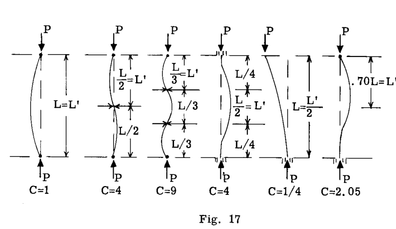

図17

## A18.24 Design Column Curves for Various Materials.

日常的な設計目的には、許容破壊柱応力 $F_c$ 対有効細長比 $L'/\rho$ の柱曲線を用意しておくと便利である。式(5)において、 $F_c$ の値を仮定し、この応力に対応する接線係数 $E_t$ を求め、それから $L'/\rho$ の項を解く。表A18.1は、室温における17-7 PH (TH1050) ステンレス鋼シートの計算を示している。結果はその後、図18にプロットされ、柱強度曲線が得られる。特定の暴露時間における異なる高温下での材料についても同様のデータが計算され、結果は図18にプロットされている。図19から22は、様々な温度条件下における他の材料の柱曲線を示している。

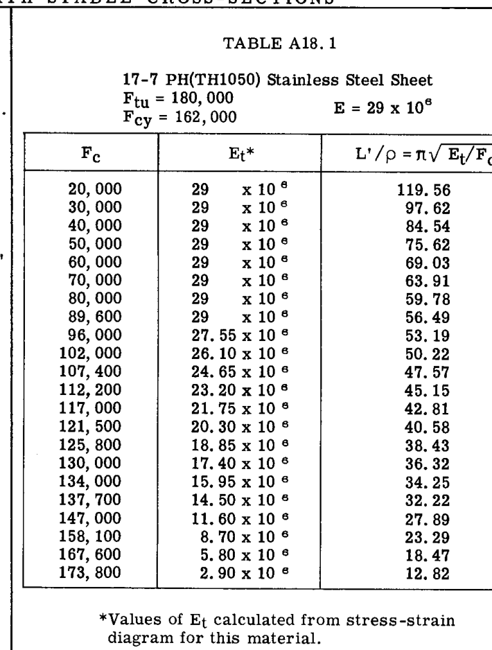

表A18.1

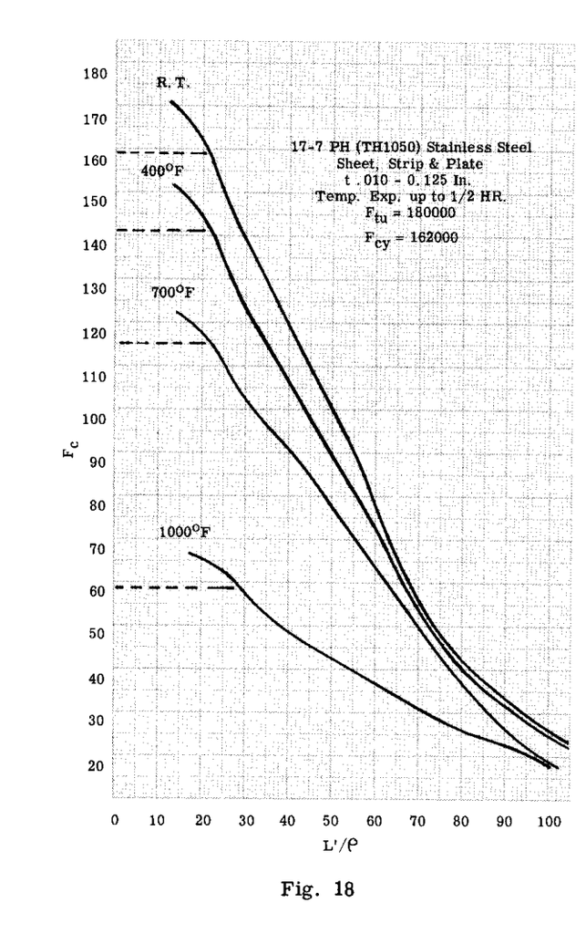

図18

## A18.25 Selection of Materials for Elevated Temperature Conditions.

軽量化は、航空宇宙構造設計において重要な要件である。応力の非弾性範囲で破壊する柱の場合、材料の $F_{cy}/w$ 比を比較すると、高温条件にさらされたときの圧縮部材の効率をかなりよく把握できる。この比において、 $F_{cy}$ は特定の温度における降伏応力であり、 $w$ は材料の1立方インチあたりの重量である。図23は、いくつかの重要な航空宇宙材料について、1/2時間の時間暴露を伴う600°Fまでの温度範囲に対する $F_{cy}/w$ のプロットを示している。

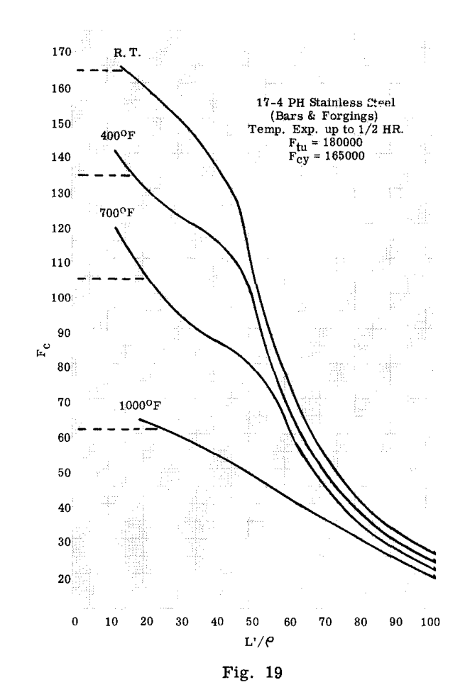

図19

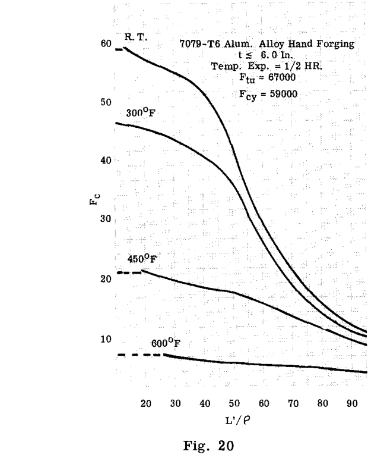

図20

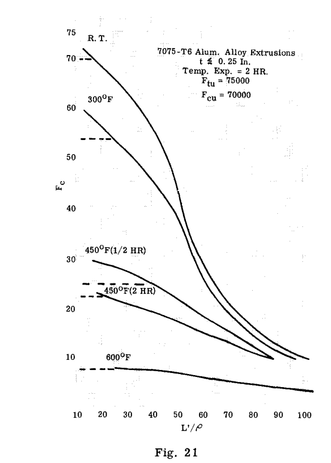

図21

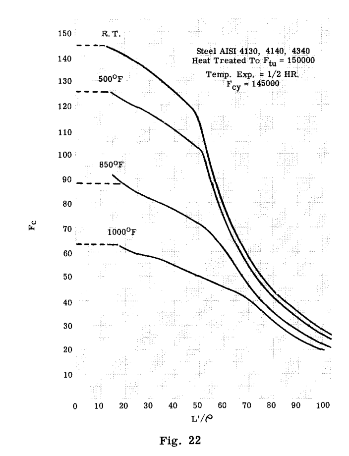

図22

## A18.26 Example Problem.

### 問題

図24は、長さ30インチの鍛造(I)断面部材を示しており、これは圧縮部材として使用される。以下の材料で作られ、指定された温度および時間条件にさらされた場合の部材の極限強度を求めよ。

Case 1. 材料 7079-T6 アルミ合金手打ち鍛造、室温。  
Case 2. Case 1と同様であるが、300°Fの温度に1/2時間さらされた場合。  
Case 3. Case 2と同様であるが、600°Fの場合。  
Case 4. 材料 17-4 PH ステンレス鋼手打ち鍛造、室温。

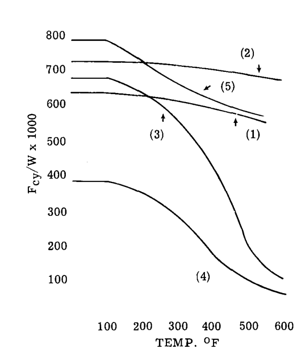

図23

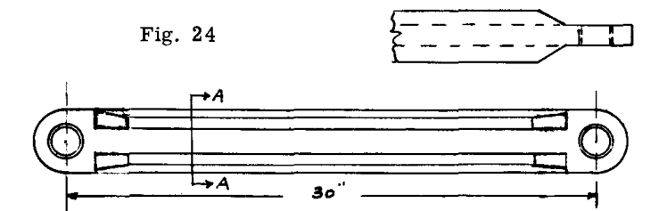

図24

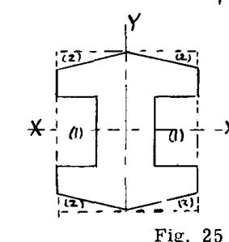

図25

### 解答

柱はX軸またはY軸の周りの曲げによって破壊する可能性があるため、これらの各軸の周りの曲げに対する柱強度を計算する。柱強度は断面の回転半径の関数であるため、解法の最初のステップは $I_x$ および $I_y$ の計算であり、これらから $\rho_x$ および $\rho_y$ を求めることができる。

$I_x$ の計算：図25において、断面は最初に $2.5 \times 2.75$ の中実の長方形とみなされ、その後、部分(1)および(2)の特性が差し引かれる。

$$I_x (\text{rectangle}) = \frac{1}{12} \times 2.5 \times 2.75^3 = 4.32$$

部分(1)および(2)

$$I_x = -\frac{1}{12} \times 1.5 \times 1.25^3 - 4(0.625 \times 0.25 \times 1.292^2) = -1.29$$

（(2)の、そのx図心軸の周りの $I_o$ は無視できる）

$$I_x = 4.32 - 1.29 = 3.03 \text{ in.}^4$$

$$\rho_x = \sqrt{\frac{I_x}{A}}$$

ここで、

$$\text{Area } A = 2.5 \times 2.75 - 2 \times 0.75 \times 1.25 - 4 \times 0.25 \times 0.625 = 4.375 \text{ sq. in.}$$

$$\rho_x = \sqrt{3.03/4.375} = 0.83 \text{ in.}$$

$I_y$ の計算：

$$I_y (\text{solid}) = \frac{1}{12} \times 2.75 \times 2.5^3 = 3.58$$

$$\text{Portion (1)} = -(1.25 \times 0.75 \times 0.875^2)2 - (1.25 \times 0.75^3/12)2 = -1.52$$

$$\text{Portion (2)} = -(0.25 \times 0.625 \times 0.833^2)4 - 4(0.25 \times 1.25^3/36) = -0.488$$

$$I_y = 3.58 - 1.52 - 0.488 = 1.58 \text{ in.}^4$$

$$\rho_y = \sqrt{1.58/4.375} = 0.60 \text{ in.}$$

柱強度は、端部拘束条件によってかなり影響を受ける。x-x軸の周りの曲げによる破壊の場合、単一のフィッティングボルトがx-x軸に平行な軸を持っているため、回転に対する端部拘束はゼロであり、したがって固定度係数 $c$ は1である。y-y軸の周りの曲げによる破壊の場合、ボルトおよび隣接するフィッティングと構造の剛性に依存する端部拘束がある。この例題では、この拘束は端部固定度係数 $c = 1.5$ となるようなものであるとする。

x-x軸周りの破壊の場合、

$$L' = L/\sqrt{c} = 30/\sqrt{1} = 30 ,\quad L'/\rho_x = 30/0.83 = 36$$

y-y軸周りの破壊の場合、

$$L' = 30/\sqrt{1.5} = 24.6 ,\quad L'/\rho_y = 24.6/0.60 = 41$$

したがって、破壊は $L'/\rho = 41$ でのy-y軸周りの曲げに対して臨界的である。

**Case 1.** 材料は7079-T6アルミ合金手打ち鍛造である。図20は、この材料の破壊応力 $F_c$ を $L'/\rho$ 比に対してプロットしたものを示している。したがって、 $L'/\rho = 41$ と室温曲線を使用すると、 $F_c = 50500 \text{ psi}$ と読み取れる。したがって、破壊荷重は $P = F_cA = 50500 \times 4.375 = 220,000 \text{ lbs}$ となる。

**Case 2.** 同じ $L'/\rho$ 値に対して図20の300°F曲線を使用すると、 $F_c = 40,400$ と読み取れ、したがって $P = 40,400 \times 4.375 = 177,000 \text{ lbs}$ となる。

**Case 3.** 600°F曲線を使用すると、 $F_c$ は6100と読み取れ、したがって $P = 6100 \times 4.375 = 26700 \text{ lbs}$ となる。したがって、この部材を600°Fの温度に1/2時間さらすと、その強度は220,000 lbsから26,700 lbsに低下する。これは、強度の低下が非常に大きいため、アルミ合金はそのような温度下で荷重を支えるには不適切な材料であることを意味している。

**Case 4.** 材料は17-4 PHステンレス鋼鍛造である。図19は、この材料の柱曲線を示している。 $L'/\rho = 41$ に対し、室温曲線を使用すると $F_c = 135,200$ と読み取れ、したがって $P = 135,200 \times 4.375 = 591,000 \text{ lbs}$ となる。

## A18.27 Comprehensive Treatment of Column Strength.

安定な断面を持つ柱は、A18.22節に記載されているように破壊する。しかし、アングル、チャンネル、ゼット形状などの開断面を持つ圧縮部材は、ねじれ、または断面を構成する1つ以上の要素の局所座屈もしくはクリップリングによって破壊することが多い。さらに、端部固定条件は柱強度に影響を与え、これらの端部条件は端部フィッティングの種類または隣接する構造への接続に依存する。さらに、重量を節約するために、柱は断面がテーパー状、すなわち柱の長さに沿って断面二次モーメントが変化することが多く、一定の断面二次モーメントを前提とするこれらの方程式(1)および(2)は適用されない。高温条件は材料の強度に影響を与えるため、構造部材の柱強度も同様に影響を受ける（図26、27、28を参照）。

この第1巻は主に構造の応力および歪み解析を扱っているため、柱強度の主題はわずかに考慮または提示されているにすぎない。しかし、主に材料と構造の強度解析および設計を扱う第2巻では、180ページ以上の理論、設計チャート、および多くの設計例題を含む、柱設計の非常に完全かつ広範な解説が提示されている。

## A18.28 Some Mechanical and Physical Properties of a Few Typical Aircraft Materials.

与えられた荷重システム下における構造物の真のたわみまたは歪みを決定するためには、構造物に使用される材料の剛性特性の値を知る必要がある。第A7章および第A8章は構造物のたわみを扱っているため、真のたわみを求めるにはヤング率( $E$ )および剛性率( $G$ )の値を知る必要がある。表A18.2は、いくつかの一般的な航空機構造材料のこれらの剛性値、および他のいくつかの強度特性を示している。

材料が様々な期間にわたって高温にさらされると、強度および剛性特性は、第2巻から引用した図26から28に示されているように、かなり影響を受ける。

航空機材料の挙動およびその機械的・物理的特性の包括的な取り扱いについては、読者は第2巻の第B1章および第B2章を参照されたい。そこでは50ページ以上がこの重要な主題に費やされている。

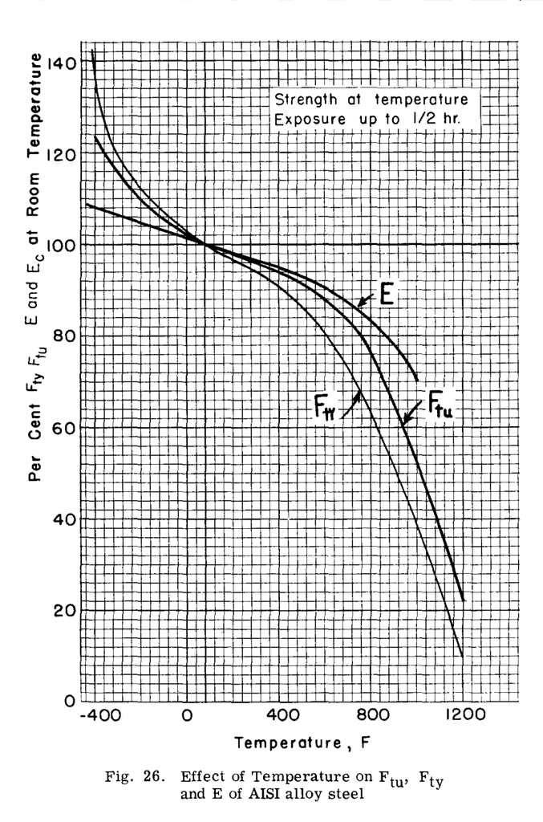

図26

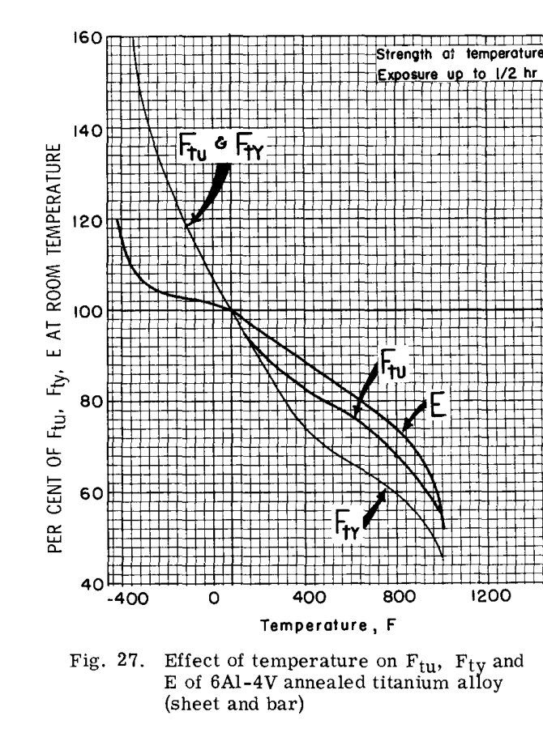

図27

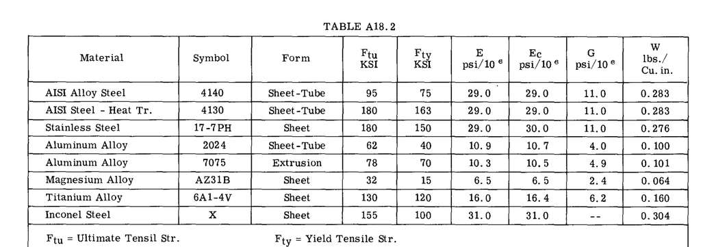

表A18.2

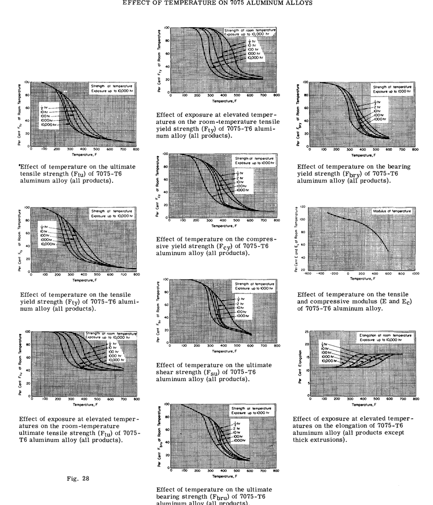

図28